# Proposal: Residential Housing Price Prediction

# Introduction

## Overview

We propose to create a linear model that can predict residential home prices in Ames, Iowa based on several explanatory variables. This project is a practical example of using real world data that consists of a mix of different data types - nominal, ordinal, discrete, and continuous variables.

Our final project will incorporate the following topics covered in this course:

- Variable manipulation
- Outlier identification
- Data analysis and interpretation
- Model building
- Model evaluation

## Description of Dataset

The 23 nominal variables identify various types of dwellings, materials, garages, and environmental conditions.

The 23 ordinal variables range from 2 to 28 representing Streets (gravel or paved) and Neighborhoods (areas within the Ames city limits).

The 14 discrete variables quantify the number of items for each house. Items include the number of kitchens, bedrooms, bathrooms, garage spaces and their respective location if the house has more than one floor.

The 20 continuous variables are related to area dimensions for each house. Variables include total dwelling square footage, total lot size, living area, and room dimensions.

Some important variables that may have strong correlation with sale price.

- `MSZoning`: Identifies the general zoning classification of the sale.
- `LotArea`: Lot size in square feet.
- `OverallQual`: Overall material and finish quality.
- `TotalBsmtSF`: Total square feet of basement area.
- `YearBuilt`: Original construction date.
- `BedroomAbvGr`: Bedrooms above grade (does NOT include basement bedrooms).
- `BsmtFullBath`: Full bathrooms above grade.
- `GarageCars`: Size of garage in car capacity.

## Dataset Source

Inspired by [`Kaggle Competition`](https://www.kaggle.com/c/house-prices-advanced-regression-techniques), the data set is provided by Dean De Cock from Truman State University. The raw data comes directly from the Iowa State Assessorʻs Office. The initial Excel file contained 113 variables describing 3,970 property sales that had occurred in Ames, Iowa between 2006 and 2010. The variables were a mix of nominal, ordinal, continuous, and discrete variables used in calculation of assessed values and included physical property measurements in addition to computation variables used in the city’s assessment process. Variables that required specific housing or assessing knowledge or previous calculations were removed from the final dataset.

# Methods

## Data Preprocessing

Change column name to comply with R variable definition

```r
BadNames =  c(FirstFlrSF = "1stFlrSF", SecondFlrSF = "2ndFlrSF", ThreeSsnPorch = "3SsnPorch")

for (i in 1:length(BadNames)) {
  colnames(house_data)[which(colnames(house_data) == BadNames[i])] = names(BadNames[i])
}
```

- Convert categorical predictor to factor and make NA an extra value
- Remove predictor with too many NAs (> 50%). In our data, NA is not a invalid value for most categorical predictors, but too many NA makes this predictor not very useful.
- Replace numerical NA with mean

```r
#Combine FullBath and HalfBath
house_data$Bath = house_data$FullBath + house_data$HalfBath * 0.5
house_data = subset(house_data, select = -c(Id, FullBath, HalfBath))

CategoricalNames = c("MSSubClass", "MSZoning", "Street", "Alley", "LotShape",
            "LandContour", "Utilities", "LotConfig", "LandSlope",
            "Neighborhood", "Condition1", "Condition2", "BldgType",
            "HouseStyle", "OverallQual", "OverallCond", "RoofStyle",
            "RoofMatl", "Exterior1st", "Exterior2nd", "MasVnrType",
            "ExterQual", "ExterCond", "Foundation", "BsmtQual",
            "BsmtCond", "BsmtExposure", "BsmtFinType1", "BsmtFinType2",
            "Heating", "HeatingQC", "CentralAir", "Electrical",
#           "BsmtFullBath", "BsmtHalfBath",
#           "FullBath","HalfBath",
#           "BedroomAbvGr", "KitchenAbvGr",
            "KitchenQual", "Functional",
#           "TotRmsAbvGrd",
#            "Fireplaces",
            "FireplaceQu",
            "GarageType","GarageFinish",
#           "GarageCars",
            "GarageQual", "GarageCond",
            "PavedDrive", "PoolQC", "Fence", "MiscFeature",
            "SaleType", "SaleCondition")

rm_index = c()
for(i in 1:ncol(house_data)) {
  nas = is.na(house_data[[i]])

  if(sum(nas) / nrow(house_data) > 0.5) {
    print(paste("(", colnames(house_data)[i], ") Removed"))
    rm_index = c(rm_index, i)

  } else {
    if(colnames(house_data)[i] %in% CategoricalNames) { #Categorical predictor
      house_data[[i]] = factor(house_data[[i]], exclude = NULL)
    } else{
      if(sum(nas) > 0) {
        house_data[[i]][nas] = mean(house_data[[i]][!nas])
      }
    }
  }
}
```

```
## [1] "( Alley ) Removed"
## [1] "( PoolQC ) Removed"
## [1] "( Fence ) Removed"
## [1] "( MiscFeature ) Removed"
```

```r
CategoricalNames = CategoricalNames[!(CategoricalNames %in% colnames(house_data)[rm_index])]
house_data = subset(house_data, select = -rm_index)
```

```r
# number of corr plots
house_cols = colnames(house_data)
x = (length(house_cols)-1)/10

for (i in 0:(x-1)){
  #pairs(num_house_data[, c(house_cols[(10*i+1):(10*(i+1))], "SalePrice")], col="dodgerblue")
}
```

```r
non_factors = c("LotFrontage", "LotArea", "YearBuilt",
                "YearRemodAdd", "MasVnrArea", "BsmtFinSF1",
                "BsmtFinSF2", "BsmtUnfSF", "TotalBsmtSF",
                "LowQualFinSF",
                "GrLivArea", "BsmtFullBath", "BsmtHalfBath",
                "BedroomAbvGr", "KitchenAbvGr",
                "TotRmsAbvGrd", "Fireplaces", "GarageYrBlt",
                "GarageCars", "GarageArea", "WoodDeckSF",
                "OpenPorchSF", "EnclosedPorch",
                "ScreenPorch", "PoolArea", "MiscVal", "SalePrice")

nf_data = data.frame(sapply(house_data[, non_factors], function(x) as.numeric(x)))
colnames(nf_data) = non_factors
nf_corr = cor(nf_data)
sort(nf_corr["SalePrice",], decreasing=TRUE)
```

```
##     SalePrice     GrLivArea    GarageCars    GarageArea   TotalBsmtSF
##    1.00000000    0.70862448    0.64040920    0.62343144    0.61358055
##  TotRmsAbvGrd     YearBuilt  YearRemodAdd    MasVnrArea   GarageYrBlt
##    0.53372316    0.52289733    0.50710097    0.47524132    0.47017745
##    Fireplaces    BsmtFinSF1   LotFrontage    WoodDeckSF   OpenPorchSF
##    0.46692884    0.38641981    0.33490085    0.32441344    0.31585623
##       LotArea  BsmtFullBath     BsmtUnfSF  BedroomAbvGr   ScreenPorch
##    0.26384335    0.22712223    0.21447911    0.16821315    0.11144657
##      PoolArea    BsmtFinSF2  BsmtHalfBath       MiscVal  LowQualFinSF
##    0.09240355   -0.01137812   -0.01684415   -0.02118958   -0.02560613
## EnclosedPorch  KitchenAbvGr
##   -0.12857796   -0.13590737
```

Histograms of the non-factor variables that are significant.

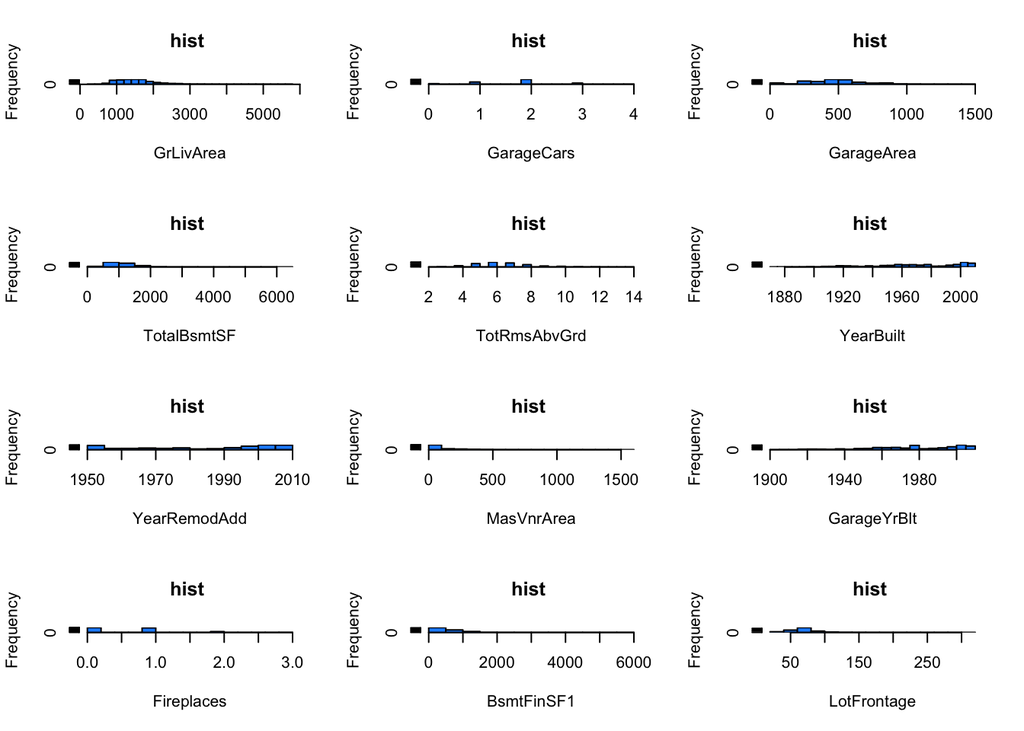

```r
top_corrs = sort(nf_corr["SalePrice", ], decreasing=TRUE)[sort(nf_corr["SalePrice", ], decreasing=TRUE) > 0]
top_corrs_name = names(top_corrs[2:length(top_corrs)])

par(mfrow=c(4,3))
for (name in top_corrs_name[1:12]){
  hist(nf_data[,name], breaks=20, xlab=name, main="hist ", col="dodgerblue")
}
```

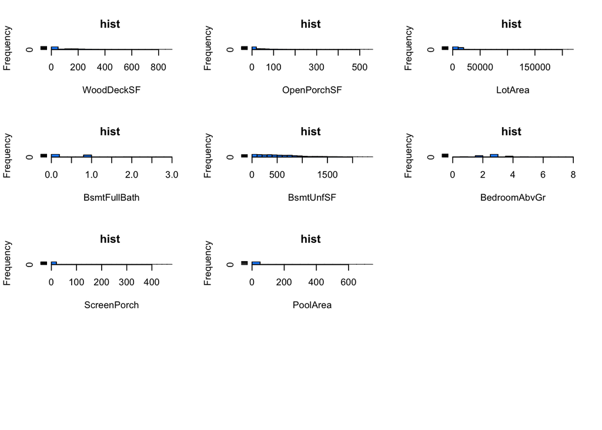

```r
par(mfrow=c(4,3))
for (name in top_corrs_name[13:length(top_corrs_name)]){
  hist(nf_data[,name], breaks=20, xlab=name, main="hist ", col="dodgerblue")
}
```

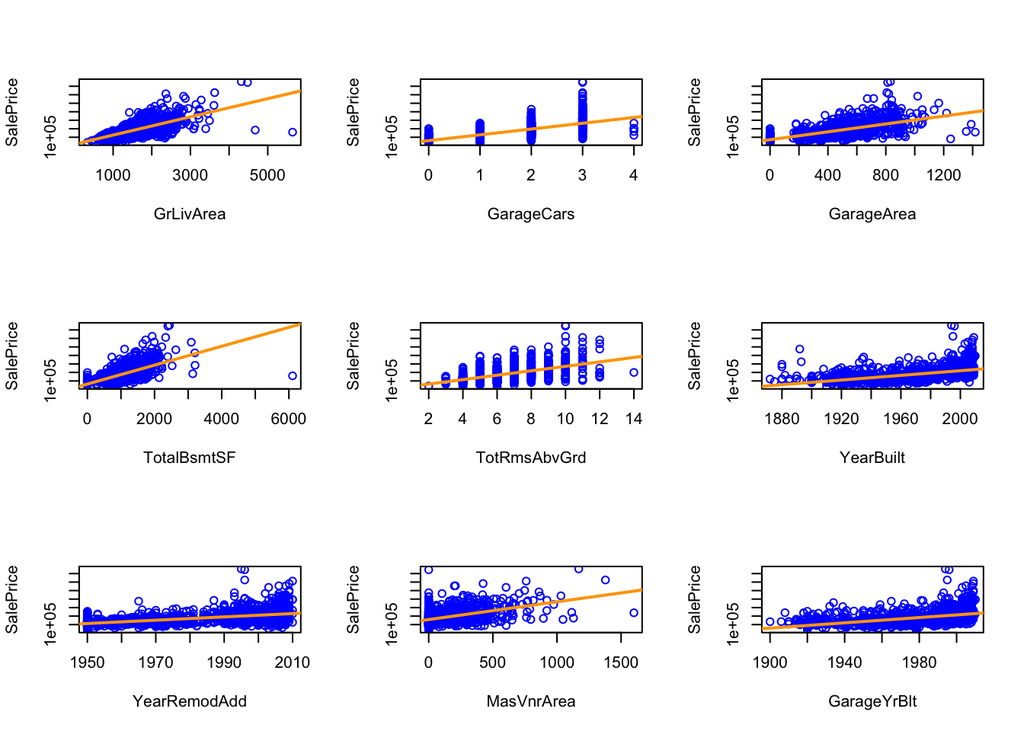

```r
par(mfrow=c(3,3))
for (name in top_corrs_name[1:9]){
  plot(nf_data[,name], house_data$SalePrice, xlab=name, ylab="SalePrice", col="blue")
  p_mod = lm(house_data$SalePrice ~ nf_data[,name])
  abline(coef(p_mod)[1], coef(p_mod)[2], col="orange", lwd=2)
}
```

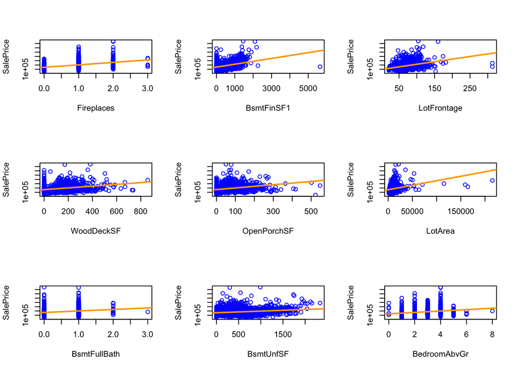

```r
par(mfrow=c(3,3))
for (name in top_corrs_name[10:18]){
  plot(nf_data[,name], house_data$SalePrice, xlab=name, ylab="SalePrice", col="blue")
  p_mod = lm(house_data$SalePrice ~ nf_data[,name])
  abline(coef(p_mod)[1], coef(p_mod)[2], col="orange", lwd=2)
}
```

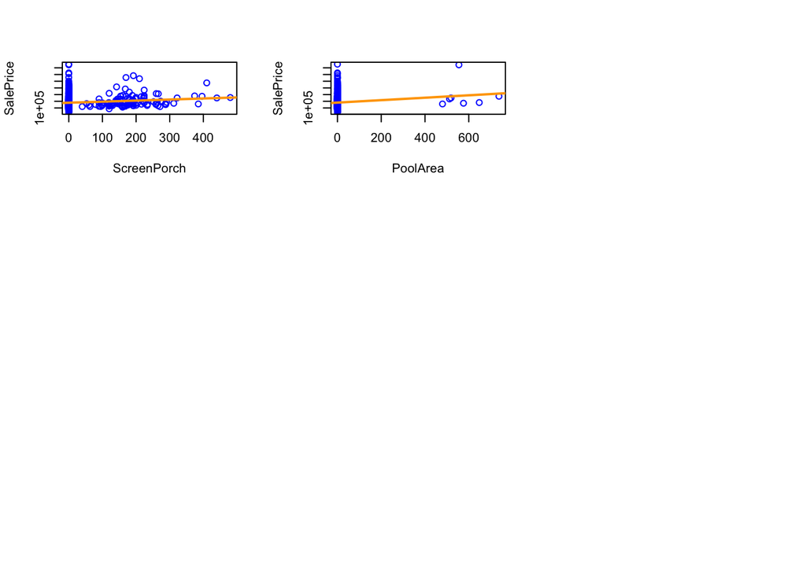

```r
par(mfrow=c(3,3))
for (name in top_corrs_name[19:length(top_corrs_name)]){
  plot(nf_data[,name], house_data$SalePrice, xlab=name, ylab="SalePrice", col="blue")
  p_mod = lm(house_data$SalePrice ~ nf_data[,name])
  abline(coef(p_mod)[1], coef(p_mod)[2], col="orange", lwd=2)
}
```

## Model Evaluation

We select the significant predictors that have high correlation with SalePrice

```r
num_house_data = house_data
for(name in colnames(num_house_data)){
  if(is.factor(num_house_data[[name]]))
    num_house_data[[name]] = as.numeric(num_house_data[[name]])
}

all_cor = cor(num_house_data)
(sig_cor = sort(abs(all_cor["SalePrice", abs(all_cor["SalePrice",]) > 0.5]), decreasing = TRUE)[-1])
```

```
##  OverallQual    GrLivArea   GarageCars    ExterQual   GarageArea
##    0.7909816    0.7086245    0.6404092    0.6368837    0.6234314
##     BsmtQual  TotalBsmtSF   FirstFlrSF         Bath  KitchenQual
##    0.6208861    0.6135806    0.6058522    0.5979656    0.5891888
## GarageFinish TotRmsAbvGrd    YearBuilt YearRemodAdd
##    0.5492468    0.5337232    0.5228973    0.5071010
```

We first build a model with predictors that has cor values > 0.5

```r
library(faraway)
sig_model = lm(build_formula("log(SalePrice)", names(sig_cor)), data = house_data)
summary(sig_model)$adj.r.squared
```

```
## [1] 0.832651
```

```r
sort(vif(sig_model)[vif(sig_model) > 5], decreasing = TRUE)
```

```
##  OverallQual5  OverallQual6  OverallQual7  OverallQual8  OverallQual4
##    181.339098    175.473020    158.865226     96.087900     65.991711
##  OverallQual9   ExterQualTA   ExterQualGd OverallQual10  OverallQual3
##     28.755945     16.703341     13.545333     13.261583     12.743679
## KitchenQualTA    BsmtQualTA KitchenQualGd     GrLivArea   TotalBsmtSF
##      9.272673      8.815756      7.315239      6.561705      6.519201
##    BsmtQualGd    GarageCars    FirstFlrSF    GarageArea
##      6.269326      6.171393      5.707146      5.403811
```

This model has good adjusted r-squared value. However, we do see many predictors has high VIFs. Although, high VIFs won’t cause big problem to prediction, too many correlated predictors dose impact our capability to search through other better models using interaction or polynomial. This could also cause problem to analyze high leverage and calculate LOOCV RMSE because not able to solve $\left(X^\top X\right)^{-1}$.

We see `OverallQual` gives us the most trouble although VIF of `OverallQual2` is 2.69807. Let’s first try to remove this predictor and see what happen.

```r
predictors = names(sig_cor)[names(sig_cor) != "OverallQual"]
no_overallqual_model = lm(build_formula("log(SalePrice)", predictors), data = house_data)
summary(no_overallqual_model)$adj.r.squared
```

```
## [1] 0.8085306
```

```r
anova(no_overallqual_model, sig_model)[2, "Pr(>F)"]
```

```
## [1] 1.434653e-38
```

However, after removing `OverallQual`, adjusted r-squared dropped 0.0241203, the significant test also reject the $OverallQual = 0$ hypothesis. All these evidences mean `OverallQual` is useful for our predicction.

Let’s check the relation between `OverallQual` and `Log(SalePrice)`

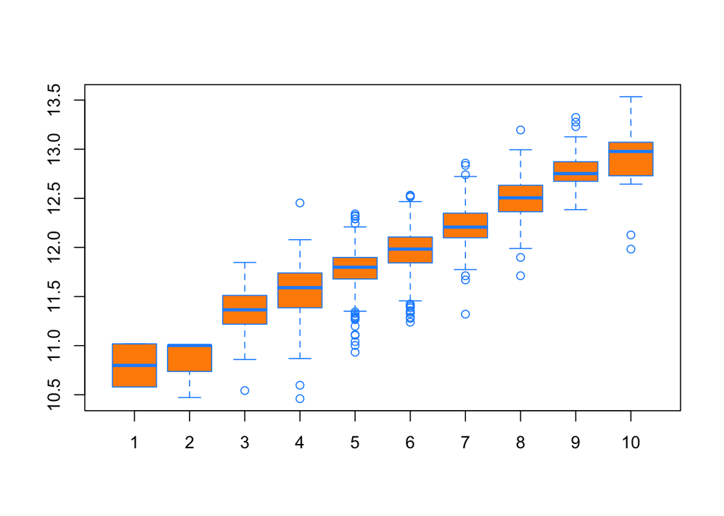

It’s quite linear and increase of 1 score of OverallQual has constant change on `log(SalePrice)`. Thus, we could convert this categorical predictor to numerical predictor.

```r
house_data$OverallQual = as.numeric(house_data$OverallQual)
model_1 = lm(build_formula("log(SalePrice)", names(sig_cor)), data = house_data)
summary(model_1)$adj.r.squared
```

```
## [1] 0.828942
```

Let’s do the similar check on `ExterQual`

```r
predictors = names(sig_cor)[names(sig_cor) != "ExterQual"]
model_2 = lm(build_formula("log(SalePrice)", predictors), data = house_data)
summary(model_2)$adj.r.squared
```

```
## [1] 0.8280178
```

```r
anova(model_2, model_1)[2, "Pr(>F)"]
```

```
## [1] 0.01322882
```

The VIFs of `GarageCars`, `TotalBsmtSF`, `KitchenQual`, `BsmtQual` and `GrLivArea` aren’t that big. We perform search to find the best model.

```r
model_aic = step(model_2, direction="backward", trace=0)
model_bic = step(model_2, direction="backward", k = log(nrow(house_data)), trace=0)
(rmse_aic  = get_loocv_rmse(model_aic))
```

```
## [1] 0.1686989
```

```r
(rmse_bic  = get_loocv_rmse(model_bic))
```

```
## [1] 0.1686989
```

```r
if(rmse_aic < rmse_aic) {
  start_model = model_aic
} else {
  start_model = model_bic
}
coef(start_model)
```

```
##     (Intercept)     OverallQual       GrLivArea      GarageCars
##    5.2907528651    0.0780723147    0.0002208174    0.0599961799
##      BsmtQualFa      BsmtQualGd      BsmtQualTA      BsmtQualNA
##   -0.1330335159   -0.0546218161   -0.0662204727   -0.2342832767
##      FirstFlrSF   KitchenQualFa   KitchenQualGd   KitchenQualTA
##    0.0001283508   -0.1557978263   -0.0611188228   -0.1031369685
## GarageFinishRFn GarageFinishUnf  GarageFinishNA       YearBuilt
##   -0.0028690648   -0.0515212252   -0.1332134980    0.0014156999
##    YearRemodAdd
##    0.0015358061
```

```r
start_predictors = attr(summary(start_model)$term,"term.labels")
remaining_predictors = colnames(house_data)[!colnames(house_data) %in% c(names(sig_cor), "SalePrice")]

#model = step(start_model, scope = build_formula("log(SalePrice)", all_predictors), direction = "forward", trace=0)
```

## Test Models

```r
set.seed(42)
train_index = sample(1:nrow(house_data), nrow(house_data)*2/3) # randomly chosen observations for training
train_data  = house_data[train_index, ]
test_data   = house_data[-train_index, ]
# retrain
model_1 = lm(build_formula("log(SalePrice)", names(sig_cor)), data = train_data)
model_2 = lm(build_formula("log(SalePrice)", predictors), data = train_data)
model_aic = step(model_2, direction="backward", trace=0)
model_bic = step(model_2, direction="backward", k = log(nrow(train_data)), trace=0)
```

Compare models on test data using RMSE as metric.

```r
## function to calculate rmse
rmse  = function(actual, predicted) {
  sqrt(mean((actual - predicted) ^ 2, na.rm=TRUE))
}

## function to compare models using rmse
compareModels <- function(models, modelNames){
  train_error = rep(0, length(modelNames))
  test_error = rep(0, length(modelNames))
  for (i in 1:length(modelNames)){
    ## train errors
    train_error[i] = rmse(log(train_data$SalePrice), predict(models[[ modelNames[i] ]], newdata=train_data))
    ## test errors
    test_error[i] = rmse(log(test_data$SalePrice), predict(models[[ modelNames[i] ]], newdata=test_data))
  }
  df = data.frame("models"=modelNames, "trainErrors"=train_error, "testErrors"=test_error)
  return(df)
}

plot_errors <- function(testData, model, model_name){
  ndf = data.frame("SalePrice"=log(testData["SalePrice"]), "pred.SalePrice" = predict(model,
                  newdata=testData))
  plot(ndf$SalePrice - ndf$pred.SalePrice, col = "blue", ylab = "Pred Errors", main = model_name)
}
```

# Results

```r
## ADD MORE MODELS HERE TO COMPARE
modelNames = c("model_1", "model_2", "model_aic", "model_bic")
models = vector(mode="list", length = length(modelNames))
models[["model_1"]] = model_1
models[["model_2"]] = model_2
models[["model_aic"]] = model_aic
models[["model_bic"]] = model_bic

compareModels(models, modelNames)
```

```
##      models trainErrors testErrors
## 1   model_1   0.1529324  0.1877037
## 2   model_2   0.1533359  0.1884751
## 3 model_aic   0.1535031  0.1876777
## 4 model_bic   0.1537378  0.1874827
```

The prediction errors for each model were also very similar.

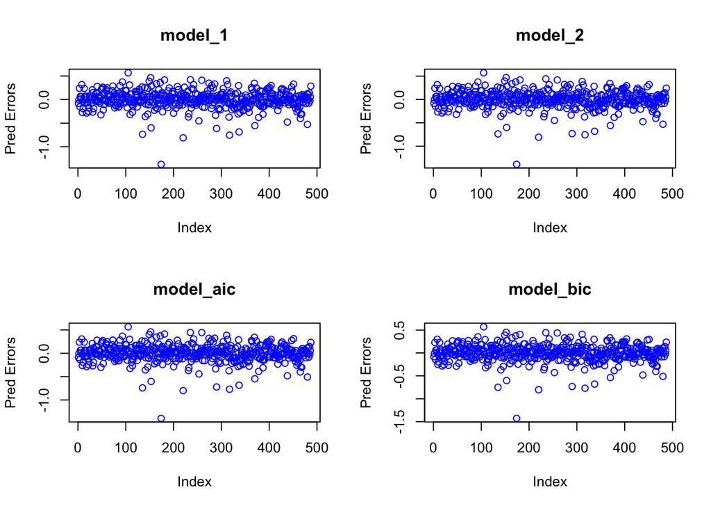

```r
## ADD MORE MODELS HERE TO COMPARE
par(mfrow=c(2, 2))
plot_errors(test_data, model_1, "model_1")
plot_errors(test_data, model_2, "model_2")
plot_errors(test_data, model_aic, "model_aic")
plot_errors(test_data, model_bic, "model_bic")
```

# Discussion

- Whether we should make discrete variables in regression model a categorical predictors?

The way to discern an interval/ratio variable is to ask if every unit increment in the variable indicates the same amount of increment in the context you wish you measure. For instance, the jump from 35 to 36 degrees is the same as the jump from 43 to 44; it’s the same amount of temperature difference. Likewise, the jump from 100 to 101 subscribers is the same as the jump from 1009 to 1010 subscribers. As long as this is true, your regression coefficient of that independent variable will make sense, because you can legitimately interpret it as the slope of the regression line.

General confusion appears when you mix in ordinal data, such as those 5-point “how satisfied are you?” questions. They are expressed in whole number, very easily to be confused with discrete data. However, each jump in the scale does not necessarily mean the same thing. E.g. a jump from “4: happy” to “5: very happy” is not necessarily the same as a jump from “1: very unhappy” to “2: unhappy.” In that case, the variable should not be put into the regression as is, but treated differently (search “dummy variable in regression” to learn more.)

# Appendix

- [`Kaggle Competition`](https://www.kaggle.com/c/house-prices-advanced-regression-techniques)
- Book
  - Applied Statistics with R by David Dalpiaz
  - An Introduction to Statistical Learning with Applications in R by Gareth James, Daniela Witten, Trevor Hastie and Robert Tibshirani
- [`Examining your data`](http://www.personal.psu.edu/jxb14/M554/articles/Hair%20et%20al%202010%20--%20Chapter%202.pdf)